# Trabajo Práctico

Análisis de datos longitudinales

Canteros, Rocio - Mac Kay, Agustina

2024-11-05

```r
knitr::opts_chunk$set(warning = FALSE, message = FALSE)
```

```r
## Paquetes utilizados
library(readxl)
library(tidyverse)
library(nlme)
library(joineR)
library(qqplotr)

# Carga de datos
esclerosis <- read_xlsx("esclerosisMultiple.xlsx")
head(esclerosis)
```

```
## # A tibble: 6 × 6
##      id   mes  afcr grupo previo  edad
##   <dbl> <dbl> <dbl> <dbl>  <dbl> <dbl>
## 1     1     0   9       1      0     0
## 2     1    12   9       1      0     0
## 3     1    15  11       1      0     0
## 4     1    18  11.5     1      0     0
## 5     2     0  10.5     1      0     0
## 6     2     6  11.2     1      0     0
```

```r
# Modificaciones
esclerosis <- esclerosis %>%
  mutate(id = factor(id),
         previo = factor(previo),
         edad = factor(edad),
         grupo = factor(grupo))
levels(esclerosis$previo) = c("No", "Si")
levels(esclerosis$edad) = c("50 años o menos", "Más de 50 años")

# Formato ancho
esclerosis_a <- esclerosis %>%
  spread(key = "mes", value = "afcr")

# Tema: fijo un tema para todos los gráficos que se hagan
theme_set(theme_bw())
```

## Análisis descriptivo

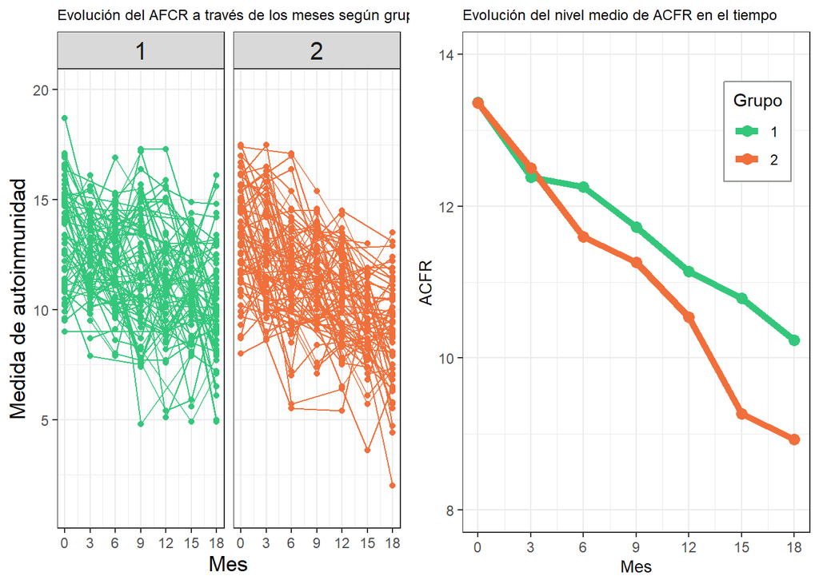

```r
### Perfiles individuales
graf_1 <- ggplot(esclerosis, aes(x = mes, y = afcr, group = id, color = grupo)) +
  geom_line(show.legend = FALSE) +
  geom_point(show.legend = FALSE) +
  facet_wrap(~ grupo) +
  scale_x_continuous("Mes", breaks = seq(0, 18, 3)) +
  scale_y_continuous("Medida de autoinmunidad") +
  coord_cartesian(ylim = c(1, 20)) +
  scale_color_manual(values = c("#34c77b", "#f16f3b")) +
  labs(title = "Evolución del AFCR a través de los meses según grupo") +
  theme(plot.title = element_text(size = 9),
        axis.title = element_text(size = 13),
        strip.text = element_text(size = 15))


# GRAFICO DE PERFILES PROMEDIO
graf_2 <- ggplot(esclerosis, aes(x = mes, y = afcr, color = grupo)) +
  stat_summary(fun = mean, geom = 'line', linewidth = 2) +
  stat_summary(fun = mean, geom = 'point', size = 3) +
  scale_color_manual(values = c("#34c77b", "#f16f3b")) +
  coord_cartesian(ylim = c(8, 14)) +
  scale_x_continuous("Mes", breaks = seq(0, 18, 3)) +
  scale_y_continuous("ACFR") +
  labs(title = "Evolución del nivel medio de ACFR en el tiempo",
       color = "Grupo", y = " ") +
  theme(plot.title = element_text(size = 9),
        axis.title = element_text(size = 10),
        strip.text = element_text(size = 10),
        legend.position = c(0.85, 0.80),
        legend.background = element_rect(fill = "white",
                                         color = "#838B83"))


gridExtra::grid.arrange(graf_1, graf_2, ncol = 2, nrow = 1)
```

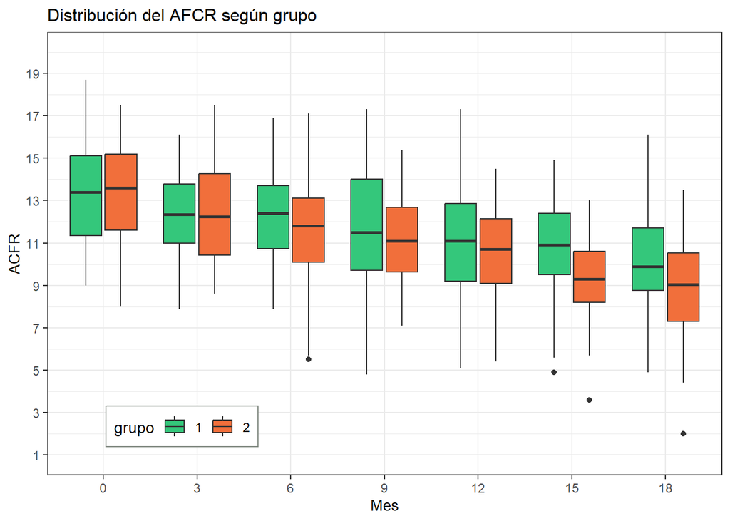

```r
# Boxplots
ggplot(esclerosis, aes(x = factor(mes), y = afcr, fill = grupo)) +
  geom_boxplot() +
  scale_x_discrete("Mes") +
  scale_y_continuous("ACFR", limits = c(1, 20), breaks = seq(1, 20, 2)) +
  scale_fill_manual(values = c("#34c77b", "#f16f3b")) +
  labs(title = "Distribución del AFCR según grupo ",
       color = "Grupo") +
  theme(plot.title = element_text(size = 12),
        axis.title = element_text(size = 10),
        legend.position = c(0.2, 0.11),
        legend.direction = "horizontal",
        legend.background = element_rect(color = "#838B83"))
```

```r
# Desvios
desvios <-esclerosis %>%
  group_by(mes, grupo) %>%
  summarise(desvio = round(sd(afcr), 2)) %>%
  arrange(grupo)

desvios <- desvios %>%
  spread(key = "mes", value = "desvio")
names(desvios)=c("grupo", "DE.0", "DE.3", "DE.6", "DE.9", "DE.12", "DE.15", "DE.18")
desvios
```

```
## # A tibble: 2 × 8
##   grupo  DE.0  DE.3  DE.6  DE.9 DE.12 DE.15 DE.18
##   <fct> <dbl> <dbl> <dbl> <dbl> <dbl> <dbl> <dbl>
## 1 1      2.31  1.82  1.98  2.8   2.47  2.16  2.44
## 2 2      2.37  2.31  2.41  1.92  2.04  1.78  2.34
```

La variancia parece disminuir levemente a medida que los meses pasan pero no pareciera diferir tanto entre los grupos. Se puede ver mejor en los desvios que no varían demasiado en el tiempo (podriamos suponer las variancias constantes)

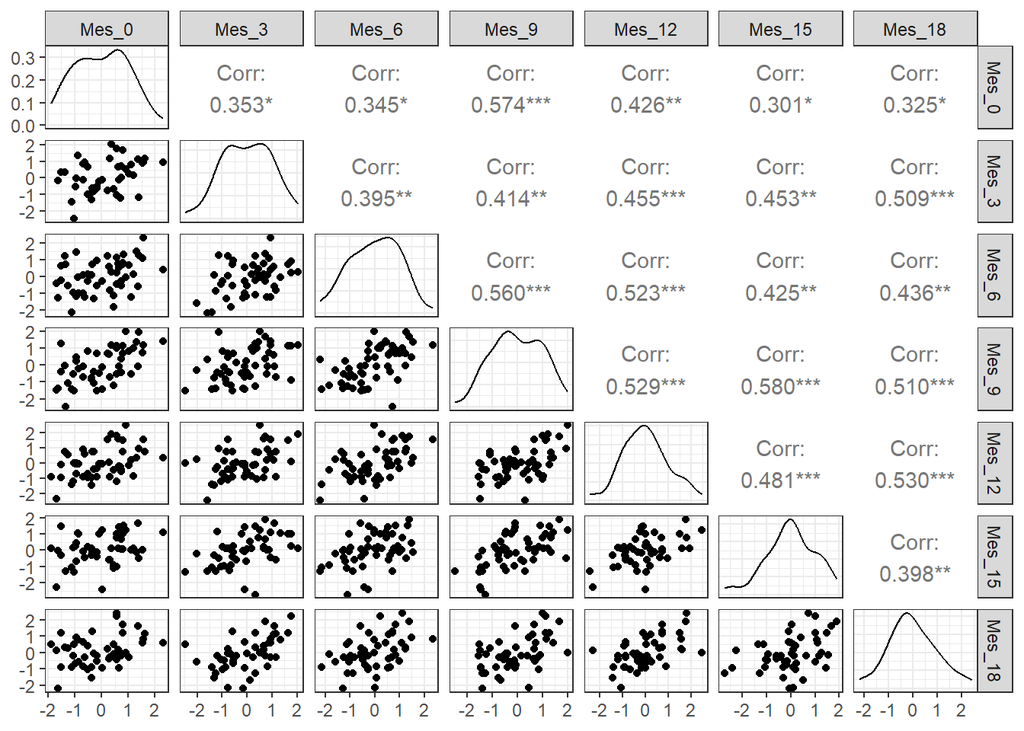

```r
# Estandarizo:
esclerosis <- esclerosis %>%
  mutate(afcr_est = scale(afcr))

esclerosis_a <- esclerosis %>%
  select(-afcr) %>%
  spread(key = "mes", value = "afcr_est")
names(esclerosis_a) <- c("id", "grupo", "previo", "edad", "Mes_0", "Mes_3",
                         "Mes_6", "Mes_9", "Mes_12", "Mes_15", "Mes_18")

# Subconjuntos
esc_1 = filter(esclerosis_a, grupo == 1)
esc_2 = filter(esclerosis_a, grupo == 2)

# Grafico de Draftman:
escl_1_est <- data.frame(scale(esc_1[5:11]))
GGally::ggpairs(escl_1_est)
```

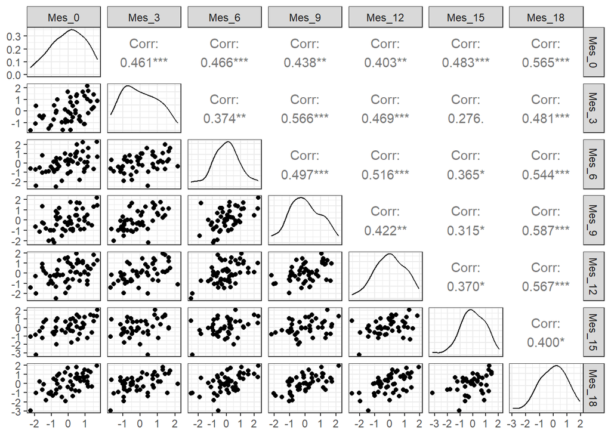

```r
escl_2_est <- data.frame(scale(esc_2[5:11]))
GGally::ggpairs(escl_2_est)
```

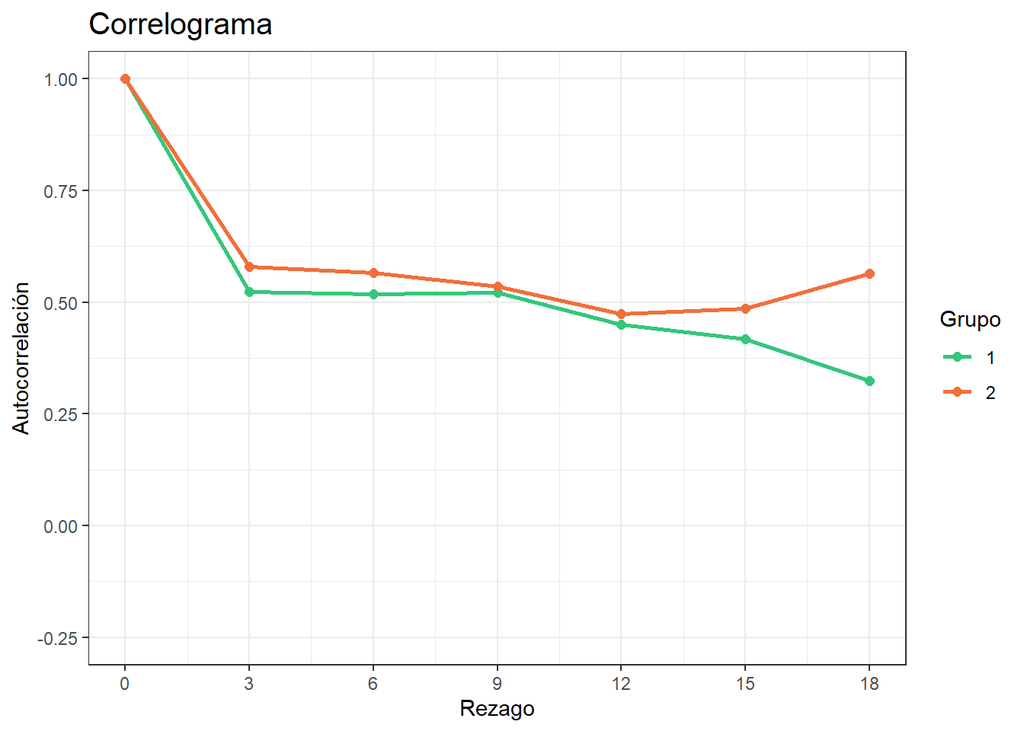

```r
# Correlograma

# Grupo 1
ac1.lag3 <- cor(c(esc_1$Mes_0, esc_1$Mes_3, esc_1$Mes_6,
                  esc_1$Mes_9, esc_1$Mes_12, esc_1$Mes_15),
                c(esc_1$Mes_3, esc_1$Mes_6, esc_1$Mes_9,
                  esc_1$Mes_12, esc_1$Mes_15, esc_1$Mes_18),
                use = "na.or.complete")

ac1.lag6 <- cor(c(esc_1$Mes_0, esc_1$Mes_3, esc_1$Mes_6,
                  esc_1$Mes_9, esc_1$Mes_12),
                c(esc_1$Mes_6, esc_1$Mes_9, esc_1$Mes_12,
                  esc_1$Mes_15, esc_1$Mes_18),
                use = "na.or.complete")

ac1.lag9 <- cor(c(esc_1$Mes_0, esc_1$Mes_3, esc_1$Mes_6,esc_1$Mes_9),
                c(esc_1$Mes_9, esc_1$Mes_12, esc_1$Mes_15,esc_1$Mes_18),
                use = "na.or.complete")

ac1.lag12 <- cor(c(esc_1$Mes_0, esc_1$Mes_3, esc_1$Mes_6),
                c(esc_1$Mes_12, esc_1$Mes_15, esc_1$Mes_18),
                use = "na.or.complete")

ac1.lag15 <- cor(c(esc_1$Mes_0, esc_1$Mes_3),
                c(esc_1$Mes_15, esc_1$Mes_18),
                use = "na.or.complete")

ac1.lag18 <- cor(c(esc_1$Mes_0),
                c(esc_1$Mes_18),
                use = "na.or.complete")

ac_grupo1 <- data.frame(rezago = seq(0,18, 3),
                        ac = c(1, ac1.lag3, ac1.lag6, ac1.lag9, ac1.lag12,
                               ac1.lag15, ac1.lag18),
                        grupo = "1")


# Grupo 2
ac2.lag3 <- cor(c(esc_2$Mes_0, esc_2$Mes_3, esc_2$Mes_6,
                  esc_2$Mes_9, esc_2$Mes_12, esc_2$Mes_15),
                c(esc_2$Mes_3, esc_2$Mes_6, esc_2$Mes_9,
                  esc_2$Mes_12, esc_2$Mes_15, esc_2$Mes_18),
                use = "na.or.complete")

ac2.lag6 <- cor(c(esc_2$Mes_0, esc_2$Mes_3, esc_2$Mes_6,
                  esc_2$Mes_9, esc_2$Mes_12),
                c(esc_2$Mes_6, esc_2$Mes_9, esc_2$Mes_12,
                  esc_2$Mes_15, esc_2$Mes_18),
                use = "na.or.complete")

ac2.lag9 <- cor(c(esc_2$Mes_0, esc_2$Mes_3, esc_2$Mes_6,esc_2$Mes_9),
                c(esc_2$Mes_9, esc_2$Mes_12, esc_2$Mes_15,esc_2$Mes_18),
                use = "na.or.complete")

ac2.lag12 <- cor(c(esc_2$Mes_0, esc_2$Mes_3, esc_2$Mes_6),
                c(esc_2$Mes_12, esc_2$Mes_15, esc_2$Mes_18),
                use = "na.or.complete")

ac2.lag15 <- cor(c(esc_2$Mes_0, esc_2$Mes_3),
                c(esc_2$Mes_15, esc_2$Mes_18),
                use = "na.or.complete")

ac2.lag18 <- cor(c(esc_2$Mes_0),
                c(esc_2$Mes_18),
                use = "na.or.complete")

ac_grupo2 <- data.frame(rezago = seq(0,18, 3),
                        ac = c(1, ac2.lag3, ac2.lag6, ac2.lag9, ac2.lag12,
                               ac2.lag15, ac2.lag18),
                        grupo = "2")

correlog <- rbind(ac_grupo1, ac_grupo2)

# Gráfico
ggplot(correlog, aes(x = rezago, y = ac, group = grupo, color = grupo)) +
  geom_point(size = 2) +
  geom_line(size = 1) +
  scale_x_continuous("Rezago", breaks = seq(0, 18, 3)) +
  scale_y_continuous("Autocorrelación", limits = c(-0.25, 1), breaks = seq(-.25, 1, 0.25)) +
  labs(title = "Correlograma", color = 'Grupo' )  +
  scale_color_manual(values = c("#34c77b", "#f16f3b")) +
  theme(plot.title = element_text(size = 15))
```

## Selección del modelo

El modelo escrito en diferencia quedaría de las siguiente manera:

$$Y_{ij} = \beta_0 + \beta_{01} \cdot P_i
+ \beta_{02} \cdot E_i + (\beta_{1} + \beta_{11} \cdot P_i + \beta_{12}
\cdot E_i + \beta_{13} \cdot G_i + \beta_{14} \cdot P_i \cdot E_i +
\beta_{15} \cdot P_i \cdot G_i + \beta_{16} \cdot E_i \cdot G_i) \cdot
t_{ij} + e_{ij}$$

Para ver qué estructura de covariancia es más adecuada para nuestros datos, lo primero que vamos a hacer es ajustar un modelo maximal para la media que no considere las correlaciones entre las mediciones repetidas.

```r
esclerosis$previo <- factor(esclerosis$previo, levels = c("No", "Si"))
esclerosis$edad <- factor(esclerosis$edad, levels = c("50 años o menos", "Más de 50 años"))

m_media <- gls(afcr ~ 1 + previo + edad + mes + grupo:mes + previo:mes + edad:mes +
                 previo:edad:mes + previo:grupo:mes + edad:grupo:mes,
              data = esclerosis)
summary(m_media)
```

```
## Generalized least squares fit by REML
##   Model: afcr ~ 1 + previo + edad + mes + grupo:mes + previo:mes + edad:mes +      previo:edad:mes + previo:grupo:mes + edad:grupo:mes
##   Data: esclerosis
##        AIC     BIC    logLik
##   3650.452 3702.48 -1814.226
##
## Coefficients:
##                                     Value  Std.Error  t-value p-value
## (Intercept)                     11.922632 0.22755344 52.39486  0.0000
## previoSi                         0.661665 0.25947722  2.54999  0.0109
## edadMás de 50 años               1.807359 0.25178582  7.17816  0.0000
## mes                             -0.178729 0.02451080 -7.29183  0.0000
## mes:grupo2                      -0.040202 0.02327427 -1.72733  0.0845
## previoSi:mes                     0.019026 0.02992450  0.63580  0.5251
## edadMás de 50 años:mes          -0.028215 0.03179498 -0.88740  0.3751
## previoSi:edadMás de 50 años:mes  0.034325 0.02693012  1.27458  0.2028
## previoSi:mes:grupo2             -0.042423 0.02681611 -1.58198  0.1140
## edadMás de 50 años:mes:grupo2   -0.008236 0.02604869 -0.31618  0.7519
##
##  Correlation:
##                                 (Intr) previS edMd50añ mes    ms:gr2 prvS:m
## previoSi                        -0.636
## edadMás de 50 años              -0.455 -0.132
## mes                             -0.711  0.450  0.327
## mes:grupo2                      -0.014  0.014 -0.002   -0.433
## previoSi:mes                     0.420 -0.667  0.088   -0.655  0.247
## edadMás de 50 años:mes           0.283  0.074 -0.607   -0.494  0.138  0.085
## previoSi:edadMás de 50 años:mes -0.004  0.007 -0.006    0.254  0.045 -0.395
## previoSi:mes:grupo2              0.014 -0.009  0.002    0.270 -0.632 -0.429
## edadMás de 50 años:mes:grupo2   -0.002  0.002 -0.001    0.198 -0.443  0.079
##                                 edMd50añ: pS:d5a prS::2
## previoSi
## edadMás de 50 años
## mes
## mes:grupo2
## previoSi:mes
## edadMás de 50 años:mes
## previoSi:edadMás de 50 años:mes -0.542
## previoSi:mes:grupo2              0.107    -0.040
## edadMás de 50 años:mes:grupo2   -0.426     0.037 -0.148
##
## Standardized residuals:
##          Min           Q1          Med           Q3          Max
## -3.152223148 -0.688044465  0.002255487  0.756335356  2.778753481
##
## Residual standard error: 2.013491
## Degrees of freedom: 847 total; 837 residual
```

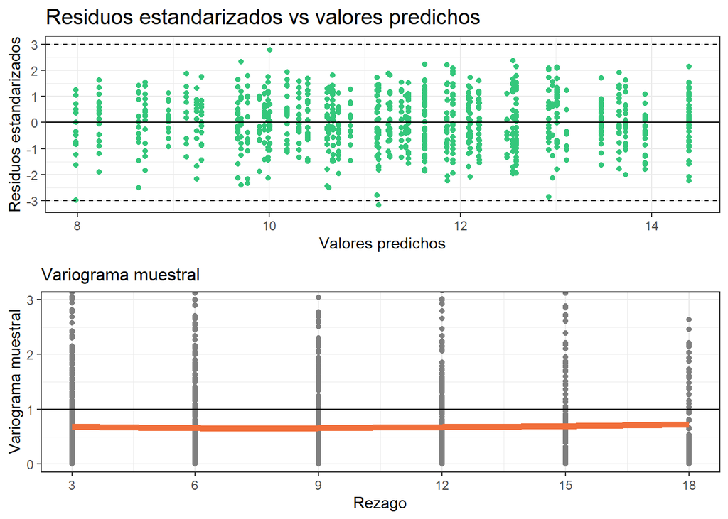

```r
resid.1 = data.frame(esclerosis, pred = fitted(m_media), resid = resid(m_media, type = "p"))

# Evaluación de la HOMOCEDASTICIDAD
# "Residuos estandarizados vs valores predichos"

graf_3 <- ggplot(data = resid.1) +
  geom_point(aes(x = pred, y = resid), color = '#34c77b') +
  geom_hline(yintercept = 0) +
  geom_hline(yintercept = c(-3, 3), linetype = 2) +
  scale_x_continuous("Valores predichos") +
  scale_y_continuous("Residuos estandarizados", breaks = seq(-3, 3, 1)) +
  labs(title = "Residuos estandarizados vs valores predichos") +
  theme(plot.title = element_text(size = 15))



# Evaluación de la ESTRUCTURA DE COVARIANCIA
# Variograma de los residuos de Cholesky

resid.1 = data.frame(resid.1, residChol = resid(m_media, type = 'n'))

vgm = variogram(resid.1$id, resid.1$mes, resid.1$residChol)
vgm1 = data.frame(vgm$svar)

graf_4 <- ggplot(data = vgm1, aes(x = vt, y = vv)) +
  geom_point(color = 'grey50') +
  geom_smooth(method = loess, se = FALSE, colour = "#f16f3b", linewidth = 2) +
  geom_hline(yintercept = 1) +
  scale_x_continuous("Rezago", breaks = seq(0, 18, 3)) +
  scale_y_continuous("Variograma muestral", breaks = seq(0, 10, 1)) +
  coord_cartesian(ylim = c(0, 3)) +
  labs(title = "Variograma muestral") +
  theme(plot.title = element_text(size = 12))

gridExtra::grid.arrange(graf_3, graf_4, nrow=2)
```

Debemos agregar un efecto aleatorio, en particular una ordenada aleatoria (más adelante evaluaremos si es necesaría agregar también una pendiente aleatoria).Por lo que el modelo quedaría así:

$$Y_{ij} = \beta_0 + \beta_{01} \cdot P_i
+ \beta_{02} \cdot E_i + b_{0i} + (\beta_{1} + \beta_{11} \cdot P_i +
\beta_{12} \cdot E_i + \beta_{13} \cdot G_i + \beta_{14} \cdot P_i \cdot
E_i + \beta_{15} \cdot P_i \cdot G_i + \beta_{16} \cdot E_i \cdot G_i)
\cdot t_{ij} + e_{ij}$$

```r
m1 <- lme(afcr ~ 1 + previo + edad + mes + previo:mes + edad:mes +
            grupo:mes + previo:edad:mes + previo:grupo:mes +
            edad:grupo:mes,
          random = ~ 1|id,
          method = "REML",
          data = esclerosis)
summary(m1)
```

```
## Linear mixed-effects model fit by REML
##   Data: esclerosis
##      AIC      BIC   logLik
##   3520.7 3577.457 -1748.35
##
## Random effects:
##  Formula: ~1 | id
##         (Intercept) Residual
## StdDev:     1.15819 1.661811
##
## Fixed effects:  afcr ~ 1 + previo + edad + mes + previo:mes + edad:mes + grupo:mes +      previo:edad:mes + previo:grupo:mes + edad:grupo:mes
##                                     Value  Std.Error  DF  t-value p-value
## (Intercept)                     11.921340 0.25606775 690 46.55541  0.0000
## previoSi                         0.622889 0.29228622 147  2.13109  0.0347
## edadMás de 50 años               1.790293 0.28411333 147  6.30133  0.0000
## mes                             -0.187758 0.02365716 690 -7.93660  0.0000
## previoSi:mes                     0.041980 0.02933497 690  1.43104  0.1529
## edadMás de 50 años:mes           0.009509 0.03239825 690  0.29349  0.7692
## mes:grupo2                      -0.037121 0.02762873 690 -1.34358  0.1795
## previoSi:edadMás de 50 años:mes -0.007876 0.03180631 690 -0.24763  0.8045
## previoSi:mes:grupo2             -0.050348 0.03172097 690 -1.58723  0.1129
## edadMás de 50 años:mes:grupo2   -0.028761 0.03085136 690 -0.93224  0.3515
##  Correlation:
##                                 (Intr) previS edMd50añ mes    prvS:m edMd50añ:
## previoSi                        -0.632
## edadMás de 50 años              -0.458 -0.133
## mes                             -0.471  0.293  0.222
## previoSi:mes                     0.272 -0.421  0.046   -0.681
## edadMás de 50 años:mes           0.182  0.041 -0.372   -0.518  0.186
## mes:grupo2                       0.015 -0.002 -0.018   -0.575  0.330  0.179
## previoSi:edadMás de 50 años:mes -0.005  0.001  0.002    0.321 -0.472 -0.638
## previoSi:mes:grupo2             -0.002  0.001  0.010    0.359 -0.532  0.121
## edadMás de 50 años:mes:grupo2   -0.018  0.011  0.003    0.265  0.076 -0.515
##                                 ms:gr2 pS:d5a prS::2
## previoSi
## edadMás de 50 años
## mes
## previoSi:mes
## edadMás de 50 años:mes
## mes:grupo2
## previoSi:edadMás de 50 años:mes  0.036
## previoSi:mes:grupo2             -0.630 -0.049
## edadMás de 50 años:mes:grupo2   -0.451  0.055 -0.142
##
## Standardized Within-Group Residuals:
##          Min           Q1          Med           Q3          Max
## -2.976380303 -0.650346440  0.002238032  0.671015436  2.467371134
##
## Number of Observations: 847
## Number of Groups: 150
```

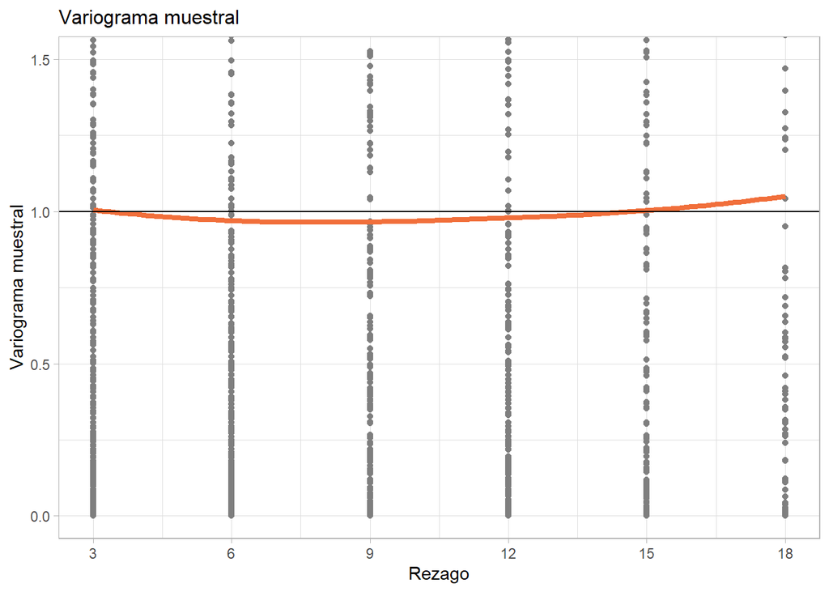

```r
resid.2 = data.frame(esclerosis, residChol = resid(m1, type = 'n', level = 0))
vgm <- variogram(resid.2$id, resid.2$mes, resid.2$residChol)
vgm2 = data.frame(vgm$svar)

ggplot(data = vgm2, aes(x = vt, y = vv)) +
  geom_point(color = 'grey50', na.rm = TRUE) +
  geom_smooth(method = 'loess',colour = "#f16f3b", se = FALSE, span = 1, linewidth = 1.5) +
  geom_hline(yintercept = 1) +
  theme_light() +
  scale_x_continuous("Rezago", breaks = seq(0, 18, 3)) +
  scale_y_continuous("Variograma muestral") +
  coord_cartesian(ylim = c(0, 1.5)) +
  labs(title = "Variograma muestral") +
  theme(plot.title = element_text(size = 12))
```

Está bastante muy cerca del 1; aún asi podríamos probar las estructuras de correlación serial (pese a que sabemos que no hay mucha) y comparar los AIC.

```r
# Exponencial
m2 <- lme(afcr ~ 1 + previo + edad + mes + previo:mes + edad:mes + grupo:mes +
            previo:edad:mes + previo:grupo:mes + edad:grupo:mes,
          method = "REML",
          random = ~ 1|id,
          correlation = corCAR1(form = ~ mes|id),
          data = esclerosis)

summary(m2)
```

```
## Linear mixed-effects model fit by REML
##   Data: esclerosis
##      AIC      BIC   logLik
##   3522.7 3584.187 -1748.35
##
## Random effects:
##  Formula: ~1 | id
##         (Intercept) Residual
## StdDev:     1.15819 1.661811
##
## Correlation Structure: Continuous AR(1)
##  Formula: ~mes | id
##  Parameter estimate(s):
##         Phi
## 0.003218309
## Fixed effects:  afcr ~ 1 + previo + edad + mes + previo:mes + edad:mes + grupo:mes +      previo:edad:mes + previo:grupo:mes + edad:grupo:mes
##                                     Value  Std.Error  DF  t-value p-value
## (Intercept)                     11.921340 0.25606772 690 46.55542  0.0000
## previoSi                         0.622889 0.29228618 147  2.13109  0.0347
## edadMás de 50 años               1.790293 0.28411329 147  6.30133  0.0000
## mes                             -0.187758 0.02365716 690 -7.93660  0.0000
## previoSi:mes                     0.041980 0.02933497 690  1.43104  0.1529
## edadMás de 50 años:mes           0.009509 0.03239825 690  0.29349  0.7692
## mes:grupo2                      -0.037121 0.02762873 690 -1.34358  0.1795
## previoSi:edadMás de 50 años:mes -0.007876 0.03180631 690 -0.24763  0.8045
## previoSi:mes:grupo2             -0.050348 0.03172097 690 -1.58723  0.1129
## edadMás de 50 años:mes:grupo2   -0.028761 0.03085136 690 -0.93224  0.3515
##  Correlation:
##                                 (Intr) previS edMd50añ mes    prvS:m edMd50añ:
## previoSi                        -0.632
## edadMás de 50 años              -0.458 -0.133
## mes                             -0.471  0.293  0.222
## previoSi:mes                     0.272 -0.421  0.046   -0.681
## edadMás de 50 años:mes           0.182  0.041 -0.372   -0.518  0.186
## mes:grupo2                       0.015 -0.002 -0.018   -0.575  0.330  0.179
## previoSi:edadMás de 50 años:mes -0.005  0.001  0.002    0.321 -0.472 -0.638
## previoSi:mes:grupo2             -0.002  0.001  0.010    0.359 -0.532  0.121
## edadMás de 50 años:mes:grupo2   -0.018  0.011  0.003    0.265  0.076 -0.515
##                                 ms:gr2 pS:d5a prS::2
## previoSi
## edadMás de 50 años
## mes
## previoSi:mes
## edadMás de 50 años:mes
## mes:grupo2
## previoSi:edadMás de 50 años:mes  0.036
## previoSi:mes:grupo2             -0.630 -0.049
## edadMás de 50 años:mes:grupo2   -0.451  0.055 -0.142
##
## Standardized Within-Group Residuals:
##         Min          Q1         Med          Q3         Max
## -2.97638038 -0.65034629  0.00223791  0.67101545  2.46737077
##
## Number of Observations: 847
## Number of Groups: 150
```

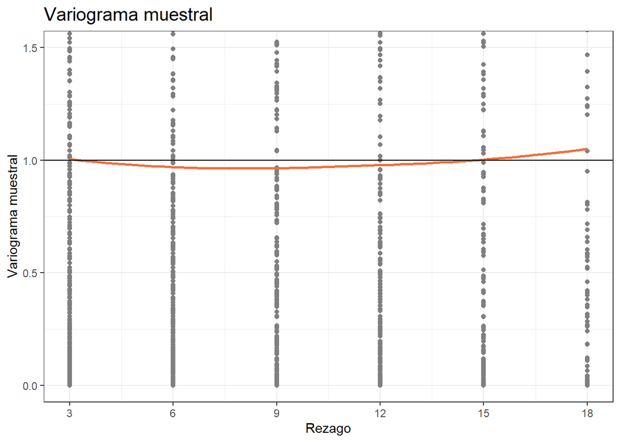

```r
resid.3 = data.frame(esclerosis, residChol = resid(m2, type = 'n', level = 0))
vgm <- variogram(resid.3$id, resid.3$mes, resid.3$residChol)
vgm3 = data.frame(vgm$svar)

ggplot(data = vgm3, aes(x = vt, y = vv)) +
  geom_point(color = 'grey50', na.rm = TRUE) +
  geom_smooth(method = 'loess',colour = "#f16f3b", se = FALSE, span = 1) +
  geom_hline(yintercept = 1) +
  scale_x_continuous("Rezago", breaks = seq(0, 18, 3)) +
  scale_y_continuous("Variograma muestral") +
  coord_cartesian(ylim = c(0, 1.5)) +
  labs(title = "Variograma muestral") +
  theme(plot.title = element_text(size = 15))
```

```r
# Gaussiana
m3 <- lme(afcr ~ 1 + previo + edad + mes + previo:mes + edad:mes + grupo:mes +
            previo:edad:mes + previo:grupo:mes + edad:grupo:mes,
          random = ~ 1|id,
          method = "REML",
          correlation = corGaus(form = ~ 1|id),
          data = esclerosis)

summary(m3)
```

```
## Linear mixed-effects model fit by REML
##   Data: esclerosis
##        AIC      BIC    logLik
##   3521.897 3583.385 -1747.948
##
## Random effects:
##  Formula: ~1 | id
##         (Intercept) Residual
## StdDev:    1.139477 1.674894
##
## Correlation Structure: Gaussian spatial correlation
##  Formula: ~1 | id
##  Parameter estimate(s):
##    range
## 0.564379
## Fixed effects:  afcr ~ 1 + previo + edad + mes + previo:mes + edad:mes + grupo:mes +      previo:edad:mes + previo:grupo:mes + edad:grupo:mes
##                                     Value  Std.Error  DF  t-value p-value
## (Intercept)                     11.921704 0.25871773 690 46.07997  0.0000
## previoSi                         0.620481 0.29528624 147  2.10129  0.0373
## edadMás de 50 años               1.795611 0.28703560 147  6.25571  0.0000
## mes                             -0.186632 0.02416567 690 -7.72303  0.0000
## previoSi:mes                     0.040927 0.02995875 690  1.36613  0.1723
## edadMás de 50 años:mes           0.006365 0.03305981 690  0.19254  0.8474
## mes:grupo2                      -0.038248 0.02808135 690 -1.36203  0.1736
## previoSi:edadMás de 50 años:mes -0.005834 0.03233319 690 -0.18042  0.8569
## previoSi:mes:grupo2             -0.049765 0.03224713 690 -1.54324  0.1232
## edadMás de 50 años:mes:grupo2   -0.026103 0.03136556 690 -0.83222  0.4056
##  Correlation:
##                                 (Intr) previS edMd50añ mes    prvS:m edMd50añ:
## previoSi                        -0.632
## edadMás de 50 años              -0.458 -0.132
## mes                             -0.480  0.300  0.226
## previoSi:mes                     0.278 -0.431  0.047   -0.680
## edadMás de 50 años:mes           0.186  0.042 -0.381   -0.517  0.182
## mes:grupo2                       0.014 -0.002 -0.017   -0.571  0.328  0.176
## previoSi:edadMás de 50 años:mes -0.005  0.001  0.001    0.318 -0.470 -0.635
## previoSi:mes:grupo2             -0.002  0.001  0.010    0.356 -0.529  0.122
## edadMás de 50 años:mes:grupo2   -0.017  0.010  0.004    0.263  0.076 -0.514
##                                 ms:gr2 pS:d5a prS::2
## previoSi
## edadMás de 50 años
## mes
## previoSi:mes
## edadMás de 50 años:mes
## mes:grupo2
## previoSi:edadMás de 50 años:mes  0.037
## previoSi:mes:grupo2             -0.629 -0.051
## edadMás de 50 años:mes:grupo2   -0.451  0.056 -0.142
##
## Standardized Within-Group Residuals:
##          Min           Q1          Med           Q3          Max
## -2.986409014 -0.650110346  0.007480169  0.671548271  2.412858168
##
## Number of Observations: 847
## Number of Groups: 150
```

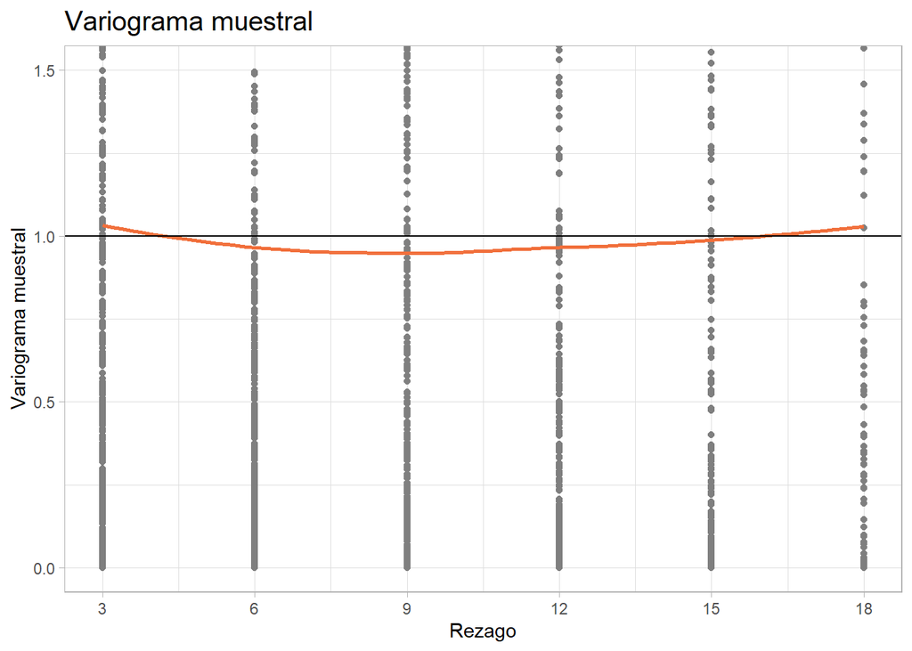

```r
resid.4 = data.frame(esclerosis, residChol = resid(m3, type = 'n', level = 0))
vgm <- variogram(resid.4$id, resid.4$mes, resid.4$residChol)
vgm4 = data.frame(vgm$svar)

ggplot(data = vgm4, aes(x = vt, y = vv)) +
  geom_point(color = 'grey50', na.rm = TRUE) +
  geom_smooth(method = 'loess',colour = "#f16f3b", se = FALSE, span = 1) +
  geom_hline(yintercept = 1) +
  theme_light() +
  scale_x_continuous("Rezago", breaks = seq(0, 18, 3)) +
  scale_y_continuous("Variograma muestral") +
  coord_cartesian(ylim = c(0, 1.5)) +
  labs(title = "Variograma muestral") +
  theme(plot.title = element_text(size = 15))
```

```r
# Comparación:
anova(m1, m2, m3)
```

```
##    Model df      AIC      BIC    logLik   Test      L.Ratio p-value
## m1     1 12 3520.700 3577.457 -1748.350
## m2     2 13 3522.700 3584.187 -1748.350 1 vs 2 6.931323e-07  0.9993
## m3     3 13 3521.897 3583.385 -1747.948
```

Decidimos que nos quedamos con el modelo con ordenada aleatoria y cuya estructura de covariancia es la Simetría Compuesta; ahora, a ese modelo, se le agrega una pendiente aleatoria y se comparan ambos modelos.

```r
m4 <- lme(afcr ~ 1 + previo + edad + mes + previo:mes + edad:mes + grupo:mes +
            previo:edad:mes + previo:grupo:mes + edad:grupo:mes,
          method = "REML",
          random = ~ mes|id,
          data = esclerosis)
summary(m4)
```

```
## Linear mixed-effects model fit by REML
##   Data: esclerosis
##        AIC     BIC    logLik
##   3524.353 3590.57 -1748.176
##
## Random effects:
##  Formula: ~mes | id
##  Structure: General positive-definite, Log-Cholesky parametrization
##             StdDev     Corr
## (Intercept) 1.11519548 (Intr)
## mes         0.01904784 0.19
## Residual    1.65741202
##
## Fixed effects:  afcr ~ 1 + previo + edad + mes + previo:mes + edad:mes + grupo:mes +      previo:edad:mes + previo:grupo:mes + edad:grupo:mes
##                                     Value  Std.Error  DF  t-value p-value
## (Intercept)                     11.920990 0.25146405 690 47.40634  0.0000
## previoSi                         0.624523 0.28701256 147  2.17594  0.0312
## edadMás de 50 años               1.790915 0.27896680 147  6.41981  0.0000
## mes                             -0.187736 0.02410821 690 -7.78722  0.0000
## previoSi:mes                     0.041905 0.02994182 690  1.39956  0.1621
## edadMás de 50 años:mes           0.009623 0.03315537 690  0.29024  0.7717
## mes:grupo2                      -0.036834 0.02843468 690 -1.29539  0.1956
## previoSi:edadMás de 50 años:mes -0.008047 0.03273322 690 -0.24583  0.8059
## previoSi:mes:grupo2             -0.050612 0.03264835 690 -1.55023  0.1215
## edadMás de 50 años:mes:grupo2   -0.028985 0.03175349 690 -0.91281  0.3617
##  Correlation:
##                                 (Intr) previS edMd50añ mes    prvS:m edMd50añ:
## previoSi                        -0.632
## edadMás de 50 años              -0.457 -0.133
## mes                             -0.453  0.282  0.214
## previoSi:mes                     0.262 -0.405  0.044   -0.682
## edadMás de 50 años:mes           0.175  0.039 -0.357   -0.518  0.189
## mes:grupo2                       0.014 -0.002 -0.017   -0.581  0.333  0.178
## previoSi:edadMás de 50 años:mes -0.005  0.001  0.002    0.323 -0.475 -0.642
## previoSi:mes:grupo2             -0.001  0.001  0.010    0.362 -0.536  0.124
## edadMás de 50 años:mes:grupo2   -0.017  0.010  0.003    0.267  0.076 -0.519
##                                 ms:gr2 pS:d5a prS::2
## previoSi
## edadMás de 50 años
## mes
## previoSi:mes
## edadMás de 50 años:mes
## mes:grupo2
## previoSi:edadMás de 50 años:mes  0.036
## previoSi:mes:grupo2             -0.629 -0.051
## edadMás de 50 años:mes:grupo2   -0.451  0.057 -0.142
##
## Standardized Within-Group Residuals:
##          Min           Q1          Med           Q3          Max
## -2.972099637 -0.658863924  0.003501433  0.665082528  2.440098311
##
## Number of Observations: 847
## Number of Groups: 150
```

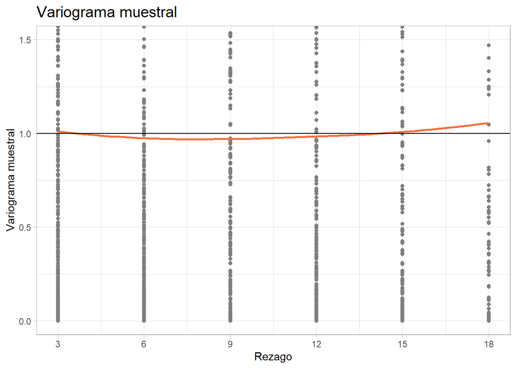

```r
resid.5 = data.frame(esclerosis, residChol = resid(m4, type = 'n', level = 0))
vgm <- variogram(resid.5$id, resid.5$mes, resid.5$residChol)
vgm5 = data.frame(vgm$svar)

ggplot(data = vgm5, aes(x = vt, y = vv)) +
  geom_point(color = 'grey50', na.rm = TRUE) +
  geom_smooth(method = 'loess',colour = "#f16f3b", se = FALSE, span = 1) +
  geom_hline(yintercept = 1) +
  theme_light() +
  scale_x_continuous("Rezago", breaks = seq(0, 18, 3)) +
  scale_y_continuous("Variograma muestral") +
  coord_cartesian(ylim = c(0, 1.5)) +
  labs(title = "Variograma muestral") +
  theme(plot.title = element_text(size = 15))
```

```r
# Comparación
anova(m1, m4)
```

```
##    Model df      AIC      BIC    logLik   Test   L.Ratio p-value
## m1     1 12 3520.700 3577.457 -1748.350
## m4     2 14 3524.353 3590.570 -1748.176 1 vs 2 0.3470065  0.8407
```

El modelos sin pendiente aleatoria resulta ser el de menor AIC, por lo que podemos asumir que las variancias son constantes a través del tiempo,¿Lo serán entre grupos? Se plantea un modelo con variancias distintas entre grupos y se lo compara con el modelo de variancias comunes.

```r
m5 <- lme(afcr ~ 1 + previo + edad + mes + previo:mes + edad:mes + grupo:mes +
            previo:edad:mes + previo:grupo:mes + edad:grupo:mes,
          random = ~ 1|id, method = "REML",
          weights = varIdent(form = ~ 1|grupo),
          data = esclerosis)
summary(m5)
```

```
## Linear mixed-effects model fit by REML
##   Data: esclerosis
##        AIC      BIC    logLik
##   3521.465 3582.953 -1747.733
##
## Random effects:
##  Formula: ~1 | id
##         (Intercept) Residual
## StdDev:    1.158927 1.709555
##
## Variance function:
##  Structure: Different standard deviations per stratum
##  Formula: ~1 | grupo
##  Parameter estimates:
##         1         2
## 1.0000000 0.9422649
## Fixed effects:  afcr ~ 1 + previo + edad + mes + previo:mes + edad:mes + grupo:mes +      previo:edad:mes + previo:grupo:mes + edad:grupo:mes
##                                     Value  Std.Error  DF  t-value p-value
## (Intercept)                     11.919417 0.25579922 690 46.59677  0.0000
## previoSi                         0.623013 0.29186759 147  2.13458  0.0345
## edadMás de 50 años               1.799628 0.28389275 147  6.33911  0.0000
## mes                             -0.188214 0.02408625 690 -7.81415  0.0000
## previoSi:mes                     0.042958 0.02979342 690  1.44186  0.1498
## edadMás de 50 años:mes           0.010331 0.03278192 690  0.31515  0.7527
## mes:grupo2                      -0.037067 0.02761385 690 -1.34235  0.1799
## previoSi:edadMás de 50 años:mes -0.010232 0.03173263 690 -0.32246  0.7472
## previoSi:mes:grupo2             -0.050318 0.03172623 690 -1.58599  0.1132
## edadMás de 50 años:mes:grupo2   -0.028928 0.03084764 690 -0.93777  0.3487
##  Correlation:
##                                 (Intr) previS edMd50añ mes    prvS:m edMd50añ:
## previoSi                        -0.631
## edadMás de 50 años              -0.460 -0.131
## mes                             -0.472  0.294  0.224
## previoSi:mes                     0.273 -0.424  0.045   -0.678
## edadMás de 50 años:mes           0.184  0.042 -0.377   -0.515  0.174
## mes:grupo2                       0.036 -0.015 -0.027   -0.599  0.344  0.188
## previoSi:edadMás de 50 años:mes -0.004  0.000  0.002    0.313 -0.463 -0.629
## previoSi:mes:grupo2             -0.015  0.021  0.008    0.373 -0.555  0.124
## edadMás de 50 años:mes:grupo2   -0.027  0.008  0.024    0.274  0.081 -0.536
##                                 ms:gr2 pS:d5a prS::2
## previoSi
## edadMás de 50 años
## mes
## previoSi:mes
## edadMás de 50 años:mes
## mes:grupo2
## previoSi:edadMás de 50 años:mes  0.036
## previoSi:mes:grupo2             -0.630 -0.049
## edadMás de 50 años:mes:grupo2   -0.450  0.055 -0.144
##
## Standardized Within-Group Residuals:
##          Min           Q1          Med           Q3          Max
## -2.910650779 -0.652671129  0.005892708  0.686319715  2.563090855
##
## Number of Observations: 847
## Number of Groups: 150
```

```r
anova(m1, m5)
```

```
##    Model df      AIC      BIC    logLik   Test  L.Ratio p-value
## m1     1 12 3520.700 3577.457 -1748.350
## m5     2 13 3521.465 3582.953 -1747.733 1 vs 2 1.234334  0.2666
```

Nuevamente, el ajuste no mejora; nos seguimos quedando con el modelo que solo tiene ordenada aleatoria.

Como última instancia, evaluamos si el modelo en realidad debe ser cuadrático en lugar de lineal; para eso, se agrega el tiempo al cuadrado.

```r
esclerosis <- mutate(esclerosis, mes2 = mes^2)

m6 <- lme(afcr ~ 1 + previo + edad + mes + previo:mes + edad:mes + grupo:mes +
            previo:edad:mes + previo:grupo:mes + edad:grupo:mes + mes2 + previo:mes2 +
            edad:mes2 + grupo:mes2 + previo:edad:mes2 + previo:grupo:mes2 +
            edad:grupo:mes2,
          random = ~ 1|id, method = "REML",
          data = esclerosis)

# Comparación:
anova(m1, m6)
```

```
##    Model df      AIC      BIC    logLik   Test L.Ratio p-value
## m1     1 12 3520.700 3577.457 -1748.350
## m6     2 19 3591.741 3681.448 -1776.871 1 vs 2 57.0417  <.0001
```

El modelo lineal está bien, por lo que el modelo final seleccionado es el propuesto al inicio: ordenada aleatoria y variancia común por grupo y tiempo.

## Análisis de residuos.

Se extraen los residuos condicionales y marginales estandarizados, los marginales de CHolesky y los valores predichos condicionales y marginales para evaluar que el modelo realmente sea adecuado.

```r
residuos <- data.frame(esclerosis,
                       res_cond_est = resid(m1, type = "p", level = 1),
                       res_marg_est = resid(m1, type = "p", level = 0),
                       res_marg_ch = resid(m1, type = "n", level = 0),
                       pred_cond = fitted(m1, level = 1),
                       pred_marg = fitted(m1, level = 0))
```

### Linealidad

Se prueba haciendo un gráfico de “residuos marginales estandarizados vs. Tiempo”.

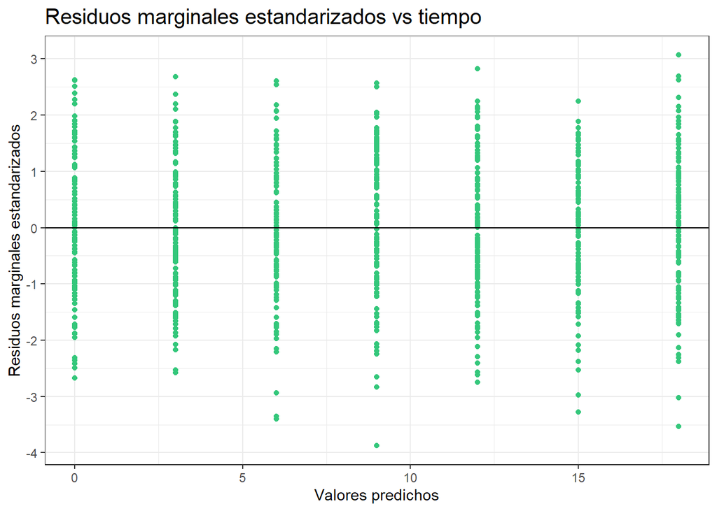

```r
ggplot(data = residuos, aes(x = mes, y = res_marg_est)) +
  geom_point(color = '#34c77b') +
  geom_hline(yintercept = 0) +
  scale_x_continuous("Valores predichos") +
  scale_y_continuous("Residuos marginales estandarizados", breaks = seq(-10, 10, 1)) +
  labs(title = "Residuos marginales estandarizados vs tiempo") +
  theme(plot.title = element_text(size = 15))
```

No hay ningún patrón visible, entonces podemos decir que el modelo para la media esta bien planteado.

Aclaración: entre estos dos gráficos va el Variograma con los residuos de Cholesky para ver la estrcutura de covariancia (ya está hecho, y mostrado, al principio)

### Homocedasticidad

Se prueba con el gráfico “Res. condicionales estandarizados vs. Predichos”

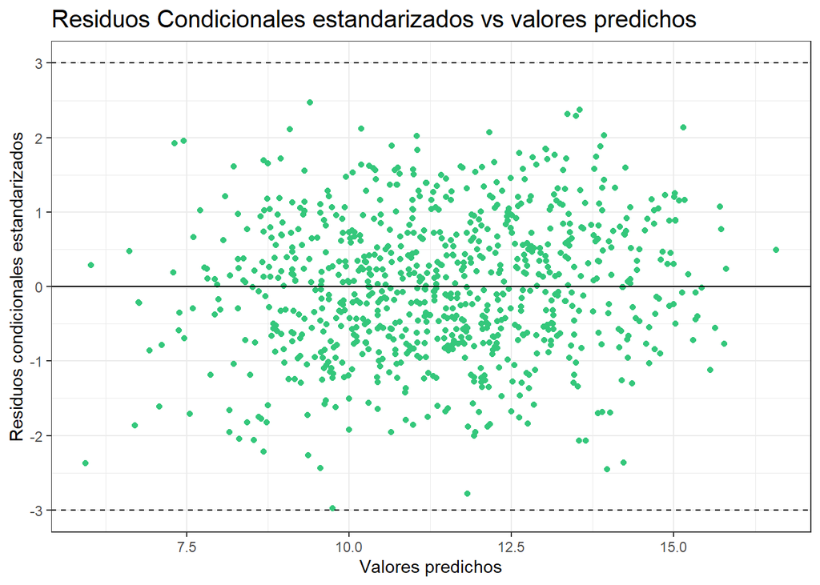

```r
ggplot(data = residuos) +
  geom_point(aes(x = pred_cond, y = res_cond_est), color = '#34c77b') +
  geom_hline(yintercept = 0) +
  geom_hline(yintercept = c(-3, 3), linetype = 2) +
  scale_x_continuous("Valores predichos") +
  scale_y_continuous("Residuos condicionales estandarizados", breaks = seq(-6, 6, 1)) +
  labs(title = "Residuos Condicionales estandarizados vs valores predichos") +
  theme(plot.title = element_text(size = 15))
```

Los puntos se observan distribuidos de manera aproximadamente aleatoria alrededor de cero y dentro de un rango constante (es decir, no hay patrón), si bien se observa un punto casi al limite (posible outlier) aun así podemos decir que el modelo para la variancia esta bien espeficado.

### Normalidad error condicional

Se prueba con un gráfico probabilistico normlar de los residuos condicionales estandarizados.

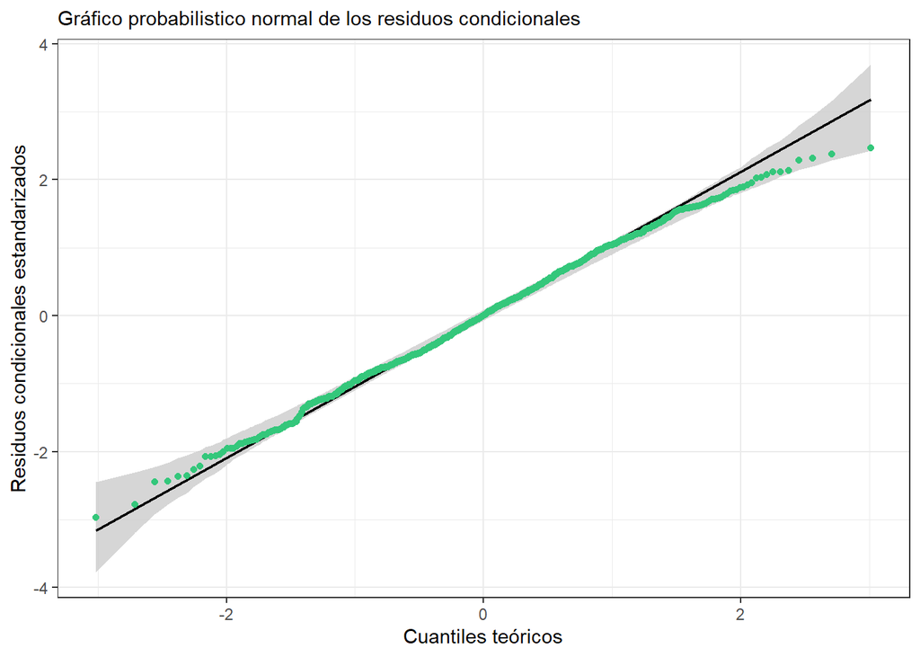

```r
ggplot(data = residuos, aes(sample = res_cond_est)) +
  stat_qq_band(bandType = 'boot', fill = 'grey80') +
  stat_qq_line() +
  stat_qq_point(color = '#34c77b') +
  labs(x = 'Cuantiles teóricos', y = 'Residuos condicionales estandarizados',
       title = 'Gráfico probabilistico normal de los residuos condicionales') +
  theme(plot.title = element_text(size = 11))
```

Hay normalidad pese a los puntos que se observan arriba.

### Normalidad de los efectos aleatorios

Se prueba con un gráfico probilistico Chi-cuadrado de la distancia de Mahalanobis.

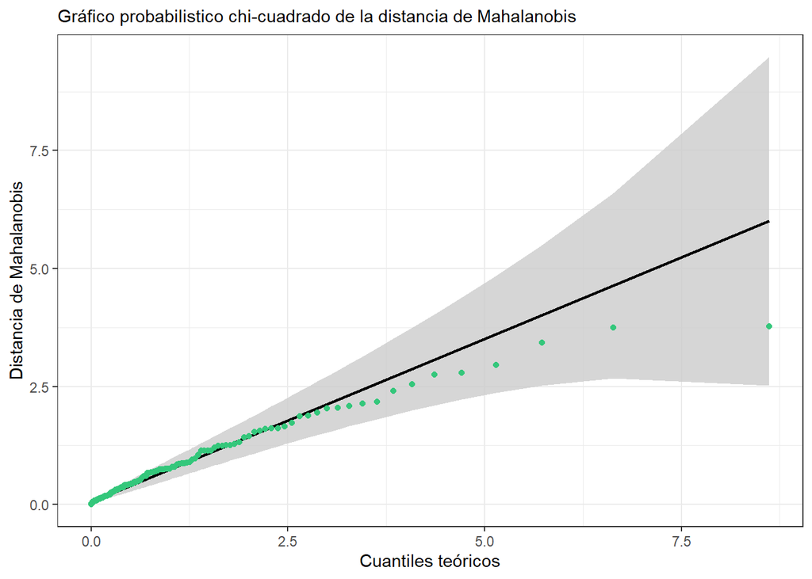

```r
# Extraemos la matriz D -variancia de los b_i-
D <-  getVarCov(m1, type = "random.effects")
M_i <- mahalanobis(ranef(m1), 0, D)
M_i <- data.frame(id = esclerosis_a$id, M_i)

# Definimos la distribución y los g.l
dist <- "chisq"
gl <- list(df = 1)

ggplot(data = M_i, aes(sample = M_i)) +
  stat_qq_band(distribution = dist, dparams = gl, fill = 'grey80') +
  stat_qq_line(distribution = dist, dparams = gl) +
  stat_qq_point(distribution = dist, dparams = gl, color = '#34c77b') +
  labs(x = 'Cuantiles teóricos', y = 'Distancia de Mahalanobis',
       title = 'Gráfico probabilistico chi-cuadrado de la distancia de Mahalanobis')+
  theme(plot.title = element_text(size = 11))
```

Se encuentran dentro de las bandas de confianza; el valor que se observa más alejado podria ser, tal vez, una observacion atipica.

### Outliers

Se pueden detectar 2 tipos de outliers: observaciones y perfiles.

#### 1) Observaciones

El gráfico que mejor los detecta es el de “Res. condicionales estudentizados vs. N° de observaciones”.

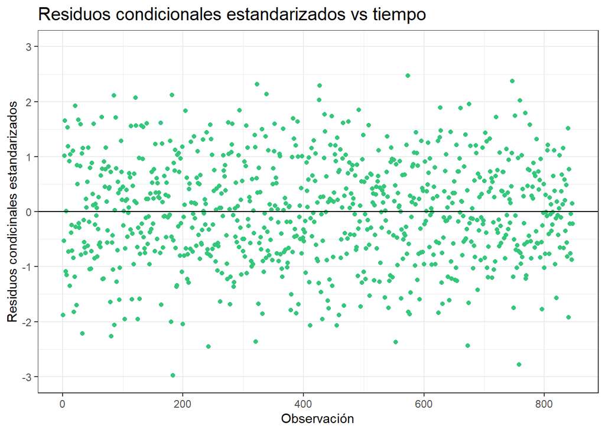

```r
# Agregamos los identificadores de observaciones
residuos <-  mutate(residuos, obs = 1:847)

ggplot(data = residuos) +
  geom_point(aes(x = obs, y = res_cond_est), color = '#34c77b') +
  geom_hline(yintercept = 0) +
  scale_x_continuous("Observación") +
  scale_y_continuous("Residuos condicinales estandarizados", breaks = seq(-6, 6, 1)) +
  coord_cartesian(ylim = c(-3, 3)) +
  labs(title = "Residuos condicionales estandarizados vs tiempo") +
  theme(plot.title = element_text(size = 15))
```

Se observa un solo punto al borde del limite del intervalo considerado para los residuos (casi -3).

#### 2) Perfiles/Individuos

Se detectan a través de un gráfico que plantea “Dist. de Mahalanobis vs. id”.

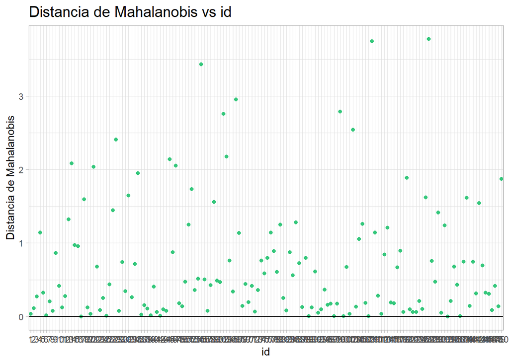

```r
ggplot(data = M_i) +
  geom_point(aes(x = id, y = M_i), color = '#34c77b') +
  geom_hline(yintercept = 0) +
  theme_light() +
#  scale_x_continuous("Individuo") +
  scale_y_continuous("Distancia de Mahalanobis") + #, breaks = seq(-6, 6, 1)) +
  labs(title = "Distancia de Mahalanobis vs id") +
  theme(plot.title = element_text(size = 15))
```

Vemos que hay 3 individuos cuyos perfiles se alejan de los demás.

Veamos, cuáles son.

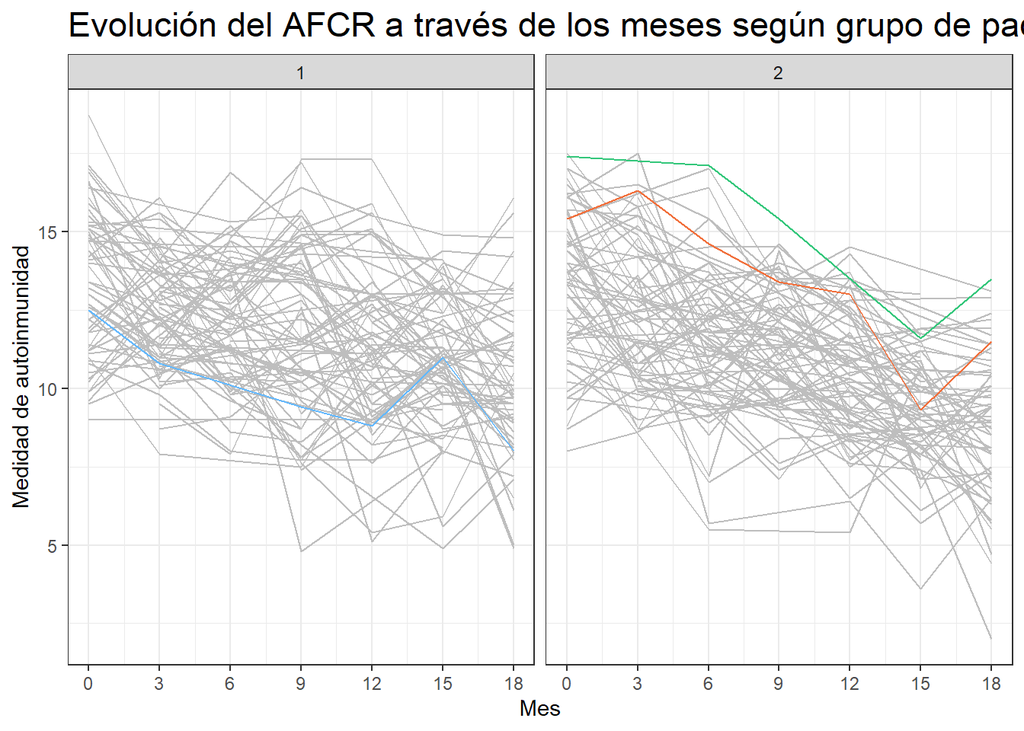

```r
ggplot() +
  geom_line(data = esclerosis, mapping = aes(x = mes, y = afcr, group = id),
            size = 0.5, na.rm = T, color = 'grey') +
  geom_point(size = 0.5, na.rm = T, color = 'grey') +
  geom_line(data = filter(esclerosis,id == 127), mapping = aes(x = mes, y = afcr),
            size = 0.5, na.rm = T, color = '#f16f3b') +
  geom_line(data = filter(esclerosis,id == 109), mapping = aes(x = mes,y = afcr),
            size = 0.5, na.rm = T, color = '#34c77b') +
  geom_line(data = filter(esclerosis,id == 55), mapping = aes(x = mes, y = afcr),
            size = 0.5, na.rm = T, color = '#63B8FF') +
  facet_wrap(~ grupo) +
  scale_x_continuous("Mes", breaks = seq(0, 18, 3)) +
  scale_y_continuous("Medidad de autoinmunidad") +
  labs(title = "Evolución del AFCR a través de los meses según grupo de pacientes") +
  theme(plot.title = element_text(size = 17))
```

Si bien las distancias de Mahalanobis de estos 3 individuos se alejan de las demás, sus perfiles parecerían estar bastante esntre mezclados con los otros.

## Test de hipótesis

Recordemos que el modelo:

$$Y_{ij} = \beta_0 + \beta_{01} \cdot P_i + \beta_{02} \cdot E_i +
(\beta_{1} + \beta_{11} \cdot P_i + \beta_{12} \cdot E_i + \beta_{13}
\cdot G_i + \beta_{14} \cdot P_i \cdot E_i + \beta_{15} \cdot P_i \cdot
G_i + \beta_{16} \cdot E_i \cdot G_i) \cdot t_{ij} + e_{ij}$$

### Hipótesis 1

¿El nivel medio de AFCR antes de comenzar el tratamiento está asociado con la edad del paciente o el hecho de haber recibido tratamiento previo con esas drogas?

Entonces queremos probar que $H_0) \beta_{01} = \beta_{02} = 0$

```r
# Re-ajusto el modelo con Maxima Verosimilitud
m1 <- update(m1, method = "ML", data = esclerosis)

m1_1 <- update(m1, fixed = ~ 1 + mes + previo:mes +edad:mes + grupo:mes +
                 previo:mes + previo:edad:mes + previo:grupo:mes + edad:grupo:mes,
               data = esclerosis)

anova(m1, m1_1) #Rechazo H0
```

```
##      Model df      AIC     BIC    logLik   Test  L.Ratio p-value
## m1       1 12 3474.499 3531.40 -1725.250
## m1_1     2 10 3516.733 3564.15 -1748.367 1 vs 2 46.23343  <.0001
```

Como rechazamos la hipótesis nula, entonces el nivel de AFCR antes de iniciar el tratamiento se ve afectado por la Edad y por el tratamiento Previo.

### Hipótesis 2

¿La tasa de cambio típica del nivel AFCR difiere entre ambos tratamientos?

La idea es igualar a 0 todos los parámetros en la pendiente relacionados al Grupo.

La hipótesis nula a probar es $H_0)\, \beta_{13} = \beta_{15} = \beta_{16} = 0$

```r
m1_3 <- update(m1, fixed = ~ 1 + previo + edad + mes + previo:mes + edad:mes +
            previo:edad:mes,
               data = esclerosis)

anova(m1, m1_3) #Rechazo H0
```

```
##      Model df      AIC      BIC   logLik   Test  L.Ratio p-value
## m1       1 12 3474.499 3531.400 -1725.25
## m1_3     2  9 3501.259 3543.935 -1741.63 1 vs 2 32.75992  <.0001
```

Rechazamos H0), la tasa de cambio típica difiere entre ambos Grupos (tratamientos)

### Hipótesis 3

¿La tasa de cambio del nivel medio de AFCR depende de la edad del paciente y/o el hecho de haber recibido tratamiento previo con alguna de estas drogas?

Las hipótesis a probar son:

- $H_0) \beta_{12} = \beta_{14} = \beta_{16} = 0$ para la Edad.
- $H_0) \beta_{11} = \beta_{14} = \beta_{15} = 0$ para el tratamiento Previo.

```r
# Edad
m1_4 <- update(m1, fixed = ~ 1 + previo + edad + mes +
                 previo:mes + grupo:mes + previo:grupo:mes,
               data = esclerosis)

anova(m1, m1_4) # No Rechazo H0
```

```
##      Model df      AIC     BIC    logLik   Test  L.Ratio p-value
## m1       1 12 3474.499 3531.40 -1725.250
## m1_4     2  9 3469.645 3512.32 -1725.822 1 vs 2 1.145225  0.7662
```

```r
# Previo

m1_5 <- update(m1, fixed = ~ 1 + previo + edad + mes +
                 edad:mes + grupo:mes + edad:grupo:mes,
               data = esclerosis)

anova(m1, m1_5) # No Rechazo H0
```

```
##      Model df      AIC      BIC    logLik   Test  L.Ratio p-value
## m1       1 12 3474.499 3531.400 -1725.250
## m1_5     2  9 3471.534 3514.209 -1726.767 1 vs 2 3.034356  0.3864
```

Ni la edad del paciente ni el tratamiento previo tienen efecto sobre la disminución media del nivel de AFCR.

### Objetivo 4

Obtener estimaciones de la tasa de cambio promedio para cada grupo de pacientes.

```r
summary(m1)
```

```
## Linear mixed-effects model fit by maximum likelihood
##   Data: esclerosis
##        AIC    BIC   logLik
##   3474.499 3531.4 -1725.25
##
## Random effects:
##  Formula: ~1 | id
##         (Intercept) Residual
## StdDev:    1.134969 1.655416
##
## Fixed effects:  afcr ~ 1 + previo + edad + mes + previo:mes + edad:mes + grupo:mes +      previo:edad:mes + previo:grupo:mes + edad:grupo:mes
##                                     Value  Std.Error  DF  t-value p-value
## (Intercept)                     11.921230 0.25472123 690 46.80108  0.0000
## previoSi                         0.623316 0.29074224 147  2.14388  0.0337
## edadMás de 50 años               1.790589 0.28260336 147  6.33605  0.0000
## mes                             -0.187585 0.02364866 690 -7.93217  0.0000
## previoSi:mes                     0.041645 0.02931902 690  1.42041  0.1559
## edadMás de 50 años:mes           0.008872 0.03236714 690  0.27412  0.7841
## mes:grupo2                      -0.037187 0.02755736 690 -1.34942  0.1776
## previoSi:edadMás de 50 años:mes -0.007193 0.03172692 690 -0.22673  0.8207
## previoSi:mes:grupo2             -0.050292 0.03164132 690 -1.58944  0.1124
## edadMás de 50 años:mes:grupo2   -0.028359 0.03077401 690 -0.92151  0.3571
##  Correlation:
##                                 (Intr) previS edMd50añ mes    prvS:m edMd50añ:
## previoSi                        -0.632
## edadMás de 50 años              -0.457 -0.133
## mes                             -0.475  0.296  0.223
## previoSi:mes                     0.275 -0.426  0.046   -0.680
## edadMás de 50 años:mes           0.184  0.041 -0.376   -0.518  0.185
## mes:grupo2                       0.014 -0.002 -0.018   -0.574  0.329  0.178
## previoSi:edadMás de 50 años:mes -0.005  0.001  0.002    0.320 -0.471 -0.637
## previoSi:mes:grupo2             -0.002  0.000  0.010    0.358 -0.530  0.121
## edadMás de 50 años:mes:grupo2   -0.018  0.011  0.003    0.264  0.076 -0.514
##                                 ms:gr2 pS:d5a prS::2
## previoSi
## edadMás de 50 años
## mes
## previoSi:mes
## edadMás de 50 años:mes
## mes:grupo2
## previoSi:edadMás de 50 años:mes  0.036
## previoSi:mes:grupo2             -0.630 -0.049
## edadMás de 50 años:mes:grupo2   -0.451  0.055 -0.142
##
## Standardized Within-Group Residuals:
##           Min            Q1           Med            Q3           Max
## -2.9975986684 -0.6564128042  0.0008409183  0.6754204633  2.4677343005
##
## Number of Observations: 847
## Number of Groups: 150
```

[output not shown]

### Objetivo 5

Con estos resultados ¿qué recomendaciones de tratamiento darías para pacientes con esclerosis múltiple?

Les diría a los pacientes que sin importar su edad o si ya han recibido tratamiento con alguna de las drogas consideradas en esta investigación, realicen el tratamiento con azatioprina y metilprednisona, ya que mejora la inmunidad en personas con esclerosis múltiple.